# Uncertainty

Maggy Critchlow

12/4/2020

## Data and Required Packages

```r
library(ungeviz)
library(tidyverse)
library(broom)
library(emmeans)
penguins <- read_csv("penguins.csv")
```

While puzzling over what to do this week, I stumbled upon this very helpful package called `ungeviz`, produced by none other than the author of our book, Claus Wilke! Perhaps Claus Wilke should be henceforth known as Santa Claus Wilke, because finding out that this package exists was a wonderful gift.

## Confidence Strips

I thought the confidence strips from the reading looked really interesting, and so I decided that I wanted to make one for the assignment this week. While Wilke pointed out some of the problems with confidence strips, I think they are effective at visually conveying uncertainty, and the range of probabilities for the location of the mean. In the example shown on his `ungeviz` page, he overlayed error bars on top of the confidence strips, which seems like a great way to handle this. I’m going to revisit the variables I looked at during the distributions week (bill length by species and flipper length) to see if these visualizations change my opinion.

### Bill Length by Species

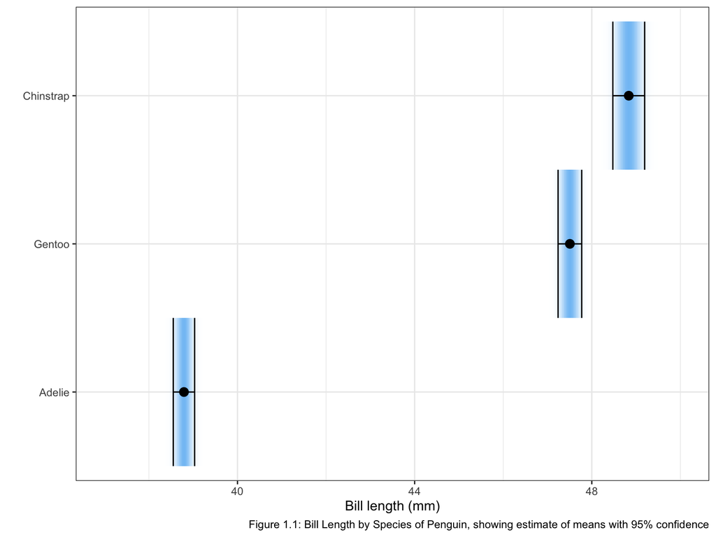

```r
bill.means <- lm(bill_length_mm ~ species, data = penguins) %>% emmeans("species") %>% tidy() %>% mutate(species = fct_reorder(species, estimate))
# Use the emmeans function to determine the mean and standard error of the data set and sort by descending order
plot1 <- ggplot(data = bill.means, aes(x = estimate, moe = std.error, y = species)) +
  stat_confidence_density(fill = "#82c3f5", height = 1, confidence = 0.95) +
  geom_point(aes(x = estimate), size = 3) +
  geom_errorbarh(aes(xmin = estimate - std.error, xmax = estimate + std.error), height = 1) + theme_bw() + xlim(37, 50) + labs(x = "Bill length (mm)", y = " ", caption = "Figure 1.1: Bill Length by Species of Penguin, showing estimate of means with 95% confidence")
plot1
```

It looks like the Gentoo and Chinstrap penguins have more similar bill lengths than Adelie penguins. This is definitely similar to the patterns visible in the density plot. There isn’t any overlap between Adelie penguin bill length and the other species’ bill lengths, which suggests that the means of bill length are different between Adelie penguins and the other species shown here.